# Cross Validate Strategy

Kevin Lu

October 23, 2017

# 1. Load Packages

```r
source("./Mean Reversion/RMR.001 Load Packages.R")
```

# 2. Load Data

```r
pricing_data <- read_csv("./Mean Reversion/Raw Data/pricing data.csv", col_types = c("iTdddddddci"))
```

# 3. Prepare Data Function

Description  
Spreads Poloneix pricing data into wide format and filters data to a specified time resolution and time window.

Arguments  
pricing_data: A dataframe containing pricing data from Poloneix gathered in tidy format.  
time_resolution: The number of seconds that each observation spans. Takes values 300, 900, 1800, 7200, 14400, and 86400.  
start_date: The start date of the time window.  
end_date: The end date of the time window.

Value  
Returns a dataframe consiting of the unix timestamp, date time, and the closing price of various currency pairs.

```r
prepare_data <- function(pricing_data, time_resolution, start_date, end_date) {
  df <- pricing_data %>%
    filter(period == time_resolution,
           date_time >= start_date,
           date_time <= end_date) %>%
    select(date_unix, date_time, close, currency_pair) %>%
    spread(currency_pair, close)
  return(df)
}
```

# 4. Test Cointegration Function

Description  
The Engle-Granger method is used to test for cointegration. This method is comprised of two steps: (1) Perform a linear regression of log(coin_y) on log(coin_x). (2) Perform an Augmented Dickey-Fuller test on the residuals from the linear regression estimated in (1). The ADF test specification is of a non-zero mean, no time-based trend, and one autoregressive lag.

Arguments  
coin_y: A vector containing the pricing data for the dependent coin in the regression.  
coin_x: A vector containing the pricing data for the independent coin in the regression.

Value  
Returns the ADF test statistic for the given coin pair.

```r
test_cointegration <- function(coin_y, coin_x) {
  lm_model <- lm.fit(y = log(coin_y), x = cbind(1, log(coin_x)))
  lm_residuals <- lm_model[["residuals"]]
  adf_test <- ur.df(lm_residuals, type = "drift", lags = 1)
  df_stat = adf_test@testreg[["coefficients"]][2, 3]
  return(df_stat)
}
```

# 5. Create Coin Pairs Function

Description  
Two sets of currency pairs are examined: currency pairs where USDT is the quote currency and currency pairs where BTC is the quote currency. All combinations of coins are created within a given quote currency. Combinations that consist of the coin with itself are removed.

Arguments  
quote_currency: A string indicating the quote currency of the currency pairs. Can take values USDT or BTC.

Value  
Returns a dataframe containing the coin pairs.

```r
create_pairs <- function(quote_currency) {
  if (quote_currency == "USDT") {
    coin_list <- c("USDT_BTC", "USDT_DASH", "USDT_ETH", "USDT_LTC", "USDT_REP", "USDT_XMR", "USDT_ZEC")
  }
  if (quote_currency == "BTC") {
    coin_list <- c("BTC_DASH", "BTC_ETH", "BTC_LTC", "BTC_REP", "BTC_XEM", "BTC_XMR", "BTC_ZEC")
  }
  coin_pairs <- expand.grid(coin_list, coin_list) %>%
    rename(coin_y = Var1,
           coin_x = Var2) %>%
    filter(coin_y != coin_x) %>%
    mutate_if(is.factor, as.character) %>%
    as_tibble()
  return(coin_pairs)
}
```

# 6. Test Coin Pairs Function

Description  
Test for cointegration between each coin pair generated by the create_pairs() function. The test for cointegration is performed by test_cointegration().

Arguments  
train: A dataframe generated by prepare_data() that represents the training set for the coin pairs.  
coin_pairs: A dataframe generated by create_pairs().

Value  
Returns a dataframe containing the coin pairs and the ADF test statistic resulting from testing cointegration between each coin pair.

```r
test_pairs <- function(train, coin_pairs) {
  adf_stat <- numeric(nrow(coin_pairs))
  for (n in 1:nrow(coin_pairs)) {
    coin_y <- coin_pairs[[n, "coin_y"]]
    coin_x <- coin_pairs[[n, "coin_x"]]
    cointegration_results <- test_cointegration(coin_y = train[[coin_y]], coin_x = train[[coin_x]])
    adf_stat[n] <- cointegration_results
  }
  df <- coin_pairs %>%
    mutate(adf_stat = adf_stat) %>%
    arrange(adf_stat)
  return(df)
}
```

# 7. Select Coin Pairs Function

Description  
Select cointegrated coin pairs to be used in a mean reversion strategy. Coin pairs are tested for cointegration using test_pairs(). Coin pairs with an ADF test statistic below a certain threshold are selected.

Arguments  
train: A dataframe generated by prepare_data() that represents the training set for the coin pair.  
coin_pairs: A dataframe generated by create_pairs().

Value  
Returns a dataframe containing the coin pairs that were selected.

```r
select_pairs <- function(train, coin_pairs) {
  df <- test_pairs(train = train, coin_pairs = coin_pairs) %>%
    filter(adf_stat <= -3.43)
  return(df)
}
```

# 8. Train Model Function

Description  
Performs rolling linear regression of log(coin y) on log(coin x) using a defined rolling window length over the test set.

Arguments  
train: A dataframe generated by prepare_data() that represents the training set for the coin pair.  
test: A dataframe generated by prepare_data() that represents the test set for the coin pair.  
coin_y: A string indicating the dependent coin in the coin pair regression.  
coin_x: A string indicating the independent coin in the coin pair regression.  
rolling_window: The number of observations used in each iteration of a rolling linear regression.

Value  
Returns a list containing the intercept and hedge ratio calculated from a rolling regression over the test set as well as the spread and z-score of the spread.

```r
train_model <- function(train, test, coin_y, coin_x, rolling_window) {

  # Perform rolling linear regression for the test set
  rolling_coef <- bind_rows(train, test) %>%
    mutate(y = log(.[[coin_y]]),
           x = log(.[[coin_x]])) %>%
    select(y, x) %>%
    rollapply(data = .,
              width = rolling_window,
              FUN = function(df) {
                df <- as_tibble(df)
                model <- lm.fit(y = df[["y"]], x = cbind(1, (df[["x"]])))
                return(model[["coefficients"]])},
              by.column = FALSE,
              fill = NA,
              align = "right") %>%
    as_tibble() %>%
    rename(intercept = x1,
           hedge_ratio = x2) %>%
    filter(row_number() > nrow(train))

  # Calculate spread in training and test set
  train <- train %>%
    mutate(spread = lm.fit(y = log(train[[coin_y]]), x = cbind(1, log(train[[coin_x]])))[["residuals"]])
  test <- test %>%
    mutate(spread = log(test[[coin_y]]) - log(test[[coin_x]]) * rolling_coef[["hedge_ratio"]] - rolling_coef[["intercept"]])

  # Combine train and test to calculate rolling z-score for the test set
  result <- bind_rows(train %>% mutate(source = "train"),
                      test %>% mutate(source = "test")) %>%
    mutate(rolling_mean = roll_mean(spread, n = rolling_window, fill = NA, align = "right"),
           rolling_sd = roll_sd(spread, n = rolling_window, fill = NA, align = "right"),
           spread_z = (spread - rolling_mean) / rolling_sd) %>%
    filter(source == "test")

  # Return list of statistics for the test set
  return(list(intercept = rolling_coef[["intercept"]],
              hedge_ratio = rolling_coef[["hedge_ratio"]],
              spread = result[["spread"]],
              spread_z = result[["spread_z"]]))
}
```

# 9. Generate Signals Function

Description  
Generate trading signals that indicate the current position in the spread formed by a trained model generated by  
train_model(). The trained model generates the spread and z-score of the spread over the test set. A signal of +1 indicates a long position in the spread, 0 indicates a flat position, and -1 indicates a short position in the spread.

Arguments  
train: A dataframe generated by prepare_data() that represents the training set for the coin pair.  
test: A dataframe generated by prepare_data() that represents the test set for the coin pair.  
coin_y: A string indicating the dependent coin in the coin pair regression.  
coin_x: A string indicating the independent coin in the coin pair regression.  
model: A trained model generated by train_model().

Value  
Returns a vector containing the trading signal over the test set.

```r
generate_signals <- function(train, test, coin_y, coin_x, model) {
  df_signals <- test %>%
    mutate(spread = model[["spread"]],
           spread_z = model[["spread_z"]],
           lag_spread_z = lag(spread_z, 1, default = 0),
           signal_long = if_else(lag_spread_z <=  0.0 & lag_spread_z > -1.0, 0.25, 0),
           signal_long = if_else(lag_spread_z <= -1.0 & lag_spread_z > -2.0, 0.50, signal_long),
           signal_long = if_else(lag_spread_z <= -2.0 & lag_spread_z > -3.0, 0.75, signal_long),
           signal_long = if_else(lag_spread_z <= -3.0 & lag_spread_z > -4.0, 1.00, signal_long),
           signal_long = if_else(lag_spread_z <= -4.0 & lag_spread_z > -5.0, 1.00, signal_long),
           signal_long = if_else(lag_spread_z <= -5.0 & lag_spread_z > -6.0, 1.00, signal_long),
           signal_long = if_else(lag_spread_z <= -6.0 & lag_spread_z > -7.0, 1.00, signal_long),
           signal_long = if_else(lag_spread_z <= -7.0, 0, signal_long),
           signal_short = if_else(lag_spread_z >= 0.0 & lag_spread_z < 1.0, -0.25, 0),
           signal_short = if_else(lag_spread_z >= 1.0 & lag_spread_z < 2.0, -0.50, signal_short),
           signal_short = if_else(lag_spread_z >= 2.0 & lag_spread_z < 3.0, -0.75, signal_short),
           signal_short = if_else(lag_spread_z >= 3.0 & lag_spread_z < 4.0, -1.00, signal_short),
           signal_short = if_else(lag_spread_z >= 4.0 & lag_spread_z < 5.0, -1.00, signal_short),
           signal_short = if_else(lag_spread_z >= 5.0 & lag_spread_z < 6.0, -1.00, signal_short),
           signal_short = if_else(lag_spread_z >= 6.0 & lag_spread_z < 7.0, -1.00, signal_short),
           signal_short = if_else(lag_spread_z >= 7.0, 0, signal_short),
           signal = signal_long + signal_short,
           signal = if_else(is.na(signal), 0, signal),
           signal = if_else(cummin(lag_spread_z) <= -7.0, 0, signal),
           signal = if_else(cummax(lag_spread_z) >=  7.0, 0, signal))
  return(df_signals[["signal"]])
}
```

# 10. Backtest Pair Function

Description  
Calculate the return of a cointegration-based mean reversion trading strategy using coin y and coin x.

The current backtesting logic uses a model generated by train_model() and trading signals generated by generate_signals(). The coin_y_return and coin_x_return indicate the one period percentage return of each coin. The coin_y_position and coin_x_position indicate the market value in USD in each coin. coin_y_pnl and coin_x_pnl indicate the USD value of the profit and loss for each coin. The combined_position indicates the gross market value of the combined positions. The return is calculated relative to the maximum capital allocation to the given coin pair.

Arguments  
train: A dataframe generated by prepare_data() that represents the training set for the coin pair.  
test: A dataframe generated by prepare_data() that represents the test set for the coin pair.  
coin_y: A string indicating the dependent coin in the coin pair regression.  
coin_x: A string indicating the independent coin in the coin pair regression.  
rolling_window: The number of observations used in each iteration of a rolling linear regression.

Value  
Returns a vector containing the cumulative return of applying the trading strategy to the given coin pair.

```r
backtest_pair <- function(train, test, coin_y, coin_x, rolling_window) {
  model <- train_model(train = train,
                       test = test,
                       coin_y = coin_y,
                       coin_x = coin_x,
                       rolling_window = rolling_window)
  df_backtest <- test %>%
    mutate(signal = generate_signals(train = train,
                                     test = test,
                                     coin_y = coin_y,
                                     coin_x = coin_x,
                                     model = model),
           coin_y_return = test[[coin_y]] / lag(test[[coin_y]], 1) - 1,
           coin_x_return = test[[coin_x]] / lag(test[[coin_x]], 1) - 1,
           coin_y_position = signal * 1                      *  1,
           coin_x_position = signal * model[["hedge_ratio"]] * -1,
           coin_y_pnl = lag(coin_y_position, 1) * coin_y_return,
           coin_x_pnl = lag(coin_x_position, 1) * coin_x_return,
           combined_position = abs(coin_y_position) + abs(coin_x_position),
           combined_pnl = coin_y_pnl + coin_x_pnl,
           combined_return = combined_pnl / (1 + abs(model[["hedge_ratio"]]))) %>%
    mutate_all(funs(ifelse(is.na(.), 0, .))) %>%
    mutate(return_pair = cumprod(1 + combined_return))
  return(df_backtest[["return_pair"]])
}
```

# 11. Backtest Strategy Function

Description  
Calculate the return of a cointegration-based mean reversion trading strategy using an equally weighted portfolio of cointegrated coin pairs. The cumulative return of each coin pair is calculated using return_pair() and the mean is taken.

Arguments  
train: A dataframe generated by prepare_data() that represents the training set for the coin pair.  
test: A dataframe generated by prepare_data() that represents the test set for the coin pair.  
selected_pairs: A dataframe generated by select_coins() that represents a set of cointegrated coin pairs.  
rolling_window: The number of observations used in each iteration of a rolling linear regression.

Value  
A vector containing the cumulative return of the overall trading strategy.

```r
backtest_strategy <- function(train, test, selected_pairs, rolling_window) {
  if (nrow(selected_pairs) == 0) {
    return(1)
  }
  df <- tibble()
  for (i in 1:nrow(selected_pairs)) {
    single_pair <- tibble(
      return_pair = backtest_pair(train = train,
                                  test = test,
                                  coin_y = selected_pairs[["coin_y"]][i],
                                  coin_x = selected_pairs[["coin_x"]][i],
                                  rolling_window = rolling_window),
      coin_y = selected_pairs[["coin_y"]][i],
      coin_x = selected_pairs[["coin_x"]][i],
      date_time = test[["date_time"]]
    )
    df <- bind_rows(df, single_pair)
  }
  df <- df %>%
    group_by(date_time) %>%
    summarise(return_strategy = mean(return_pair))
  return(df[["return_strategy"]])
}
```

# 12. Plot Single Function

Arguments  
train: A dataframe generated by prepare_data() that represents the training set for the coin pair.  
test: A dataframe generated by prepare_data() that represents the test set for the coin pair.  
coin_y: A string indicating the dependent coin in the coin pair regression.  
coin_x: A string indicating the independent coin in the coin pair regression.  
rolling_window: The number of observations used in each iteration of a rolling linear regression.

```r
plot_single <- function(train, test, coin_y, coin_x, rolling_window) {
  model <- train_model(train = train,
                       test = test,
                       coin_y = coin_y,
                       coin_x = coin_x,
                       rolling_window = rolling_window)
  df_plot <- test %>%
    mutate(spread = model[["spread"]],
           spread_z = model[["spread_z"]],
           signal = generate_signals(train = train,
                                     test = test,
                                     coin_y = coin_y,
                                     coin_x = coin_x,
                                     model = model),
           return_pair = backtest_pair(train = train,
                                       test = test,
                                       coin_y = coin_y,
                                       coin_x = coin_x,
                                       rolling_window = rolling_window),
           return_buyhold_y = test[[coin_y]] / test[[coin_y]][1],
           return_buyhold_x = test[[coin_x]] / test[[coin_x]][1])
  print(ggplot(df_plot, aes(x = date_time)) +
          geom_line(aes(y = spread_z, colour = "Spread Z"), size = 1) +
          geom_line(aes(y = signal, colour = "Signal"), size = 0.5) +
          geom_hline(yintercept = 0, colour = "red", alpha = 0.5) +
          geom_hline(yintercept = 2, colour = "red", alpha = 0.5) +
          geom_hline(yintercept = -2, colour = "red", alpha = 0.5) +
          scale_color_manual(name = "Series",
                             values = c("Spread Z" = "blue",
                                        "Signal" = "green")) +
          labs(title = "Spread vs Trading Signal",
               subtitle = str_c(coin_y, " and ", coin_x),
               x = "Date",
               y = "Spread and Signal"))
  print(ggplot(df_plot, aes(x = date_time)) +
          geom_line(aes(y = return_pair, colour = "Model"), size = 1) +
          geom_line(aes(y = return_buyhold_y, colour = "Coin Y"), size = 0.5, alpha = 0.4) +
          geom_line(aes(y = return_buyhold_x, colour = "Coin X"), size = 0.5, alpha = 0.4) +
          geom_hline(yintercept = 1, colour = "black") +
          scale_color_manual(name = "Return",
                             values = c("Model" = "darkblue",
                                        "Coin Y" = "darkred",
                                        "Coin X" = "darkgreen")) +
          labs(title = "Model Return vs Buy Hold Return",
               subtitle = str_c(coin_y, " and ", coin_x),
               x = "Date",
               y = "Cumulative Return"))
}
```

# 13. Plot Many Function

Description  
Create many plots by calling the plot_single() function multiple times. Also creates a plot showing the results of the overall strategy using backtest_strateg(). Creates a train and test set surrounding a cutoff date and creates plot for the top n coins ranked by their ADF statistic.

Arguments  
pricing_data: A dataframe containing pricing data from Poloneix gathered in tidy format.  
time_resolution: The number of seconds that each observation spans. Takes values 300, 900, 1800, 7200, 14400, and 86400.  
cutoff_date: A data representing the cutoff date between the train and test sets.  
train_window: A period object from lubridate representing the length of time the train set covers.  
test_window: A period object from lubridate representing the length of time the the test set covers. quote_currency: A string indicating the quote currency of the currency pairs. Can take values USDT or BTC.  
rolling_window: The number of observations used in each iteration of a rolling linear regression.  
number_pairs: The number of pairs to generate plots for.

Value  
Prints the plots described above.

```r
plot_many <- function(pricing_data, time_resolution, cutoff_date, train_window, test_window, quote_currency,
                      rolling_window, number_pairs) {
  train <- prepare_data(pricing_data = pricing_data,
                        time_resolution = time_resolution,
                        start_date = as.Date(cutoff_date) - train_window,
                        end_date = as.Date(cutoff_date))
  test <- prepare_data(pricing_data = pricing_data,
                       time_resolution = time_resolution,
                       start_date = as.Date(cutoff_date),
                       end_date = as.Date(cutoff_date) + test_window)
  coin_pairs <- create_pairs(quote_currency = quote_currency)
  selected_pairs <- select_pairs(train = train,
                                 coin_pairs = coin_pairs)
  if (nrow(selected_pairs) == 0) {
    return("No coin pairs selected.")
  }
  print(selected_pairs)
  for (i in 1:min(number_pairs, nrow(selected_pairs))) {
    plot_single(train = train,
                test = test,
                coin_y = selected_pairs[["coin_y"]][i],
                coin_x = selected_pairs[["coin_x"]][i],
                rolling_window = rolling_window)
  }
  test <- test %>%
    mutate(return_strategy = backtest_strategy(train = train,
                                               test = .,
                                               selected_pairs = selected_pairs,
                                               rolling_window = rolling_window))
  ggplot(test, aes(x = date_time)) +
    geom_line(aes(y = return_strategy, colour = "Strategy"), size = 1) +
    geom_line(aes(y = USDT_BTC / USDT_BTC[1], colour = "USDT_BTC"), size = 0.5, alpha = 0.4) +
    geom_hline(yintercept = 1, colour = "black") +
    scale_color_manual(name = "Return",
                       values = c("Strategy" = "darkblue",
                                  "USDT_BTC" = "darkred")) +
    labs(title = "Strategy Return vs Buy Hold Return",
         x = "Date",
         y = "Cumulative Return")
}
```

# 14. Set Parameters

```r
time_resolution <- 900
train_window <- days(32)
test_window <- days(16)
quote_currency <- "BTC"
rolling_window <- 86400 / time_resolution * as.numeric(days(2)) / 86400
number_pairs <- 3
test_by <- "16 days"
```

# 15. Cross Validation September 2017

```
## # A tibble: 11 x 3
##     coin_y  coin_x  adf_stat
##      <chr>   <chr>     <dbl>
##  1 BTC_REP BTC_ZEC -4.963602
##  2 BTC_ZEC BTC_REP -4.867776
##  3 BTC_ETH BTC_ZEC -4.129661
##  4 BTC_XEM BTC_ZEC -3.828771
##  5 BTC_ZEC BTC_ETH -3.803343
##  6 BTC_ETH BTC_XEM -3.770694
##  7 BTC_ETH BTC_REP -3.689461
##  8 BTC_XEM BTC_ETH -3.640334
##  9 BTC_ZEC BTC_XEM -3.612975
## 10 BTC_ZEC BTC_LTC -3.504784
## 11 BTC_REP BTC_ETH -3.465348
```

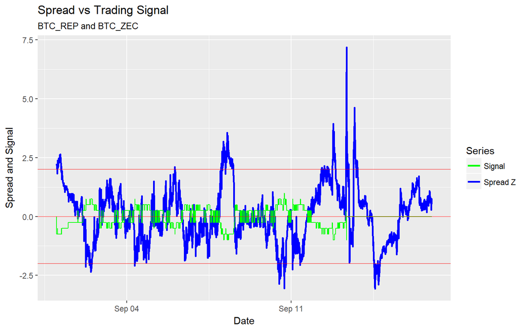

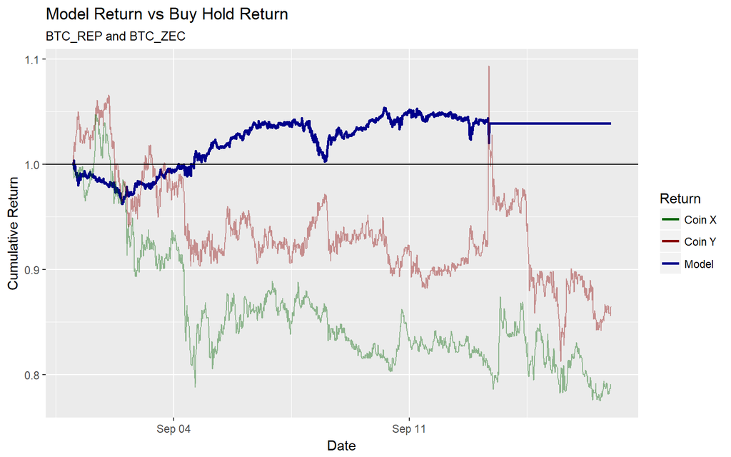

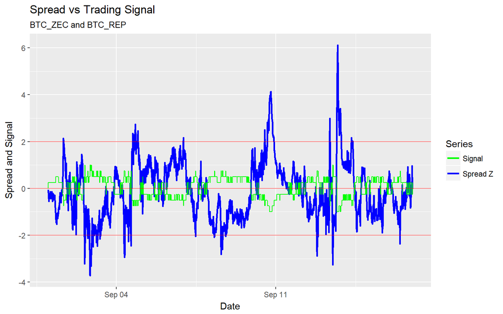

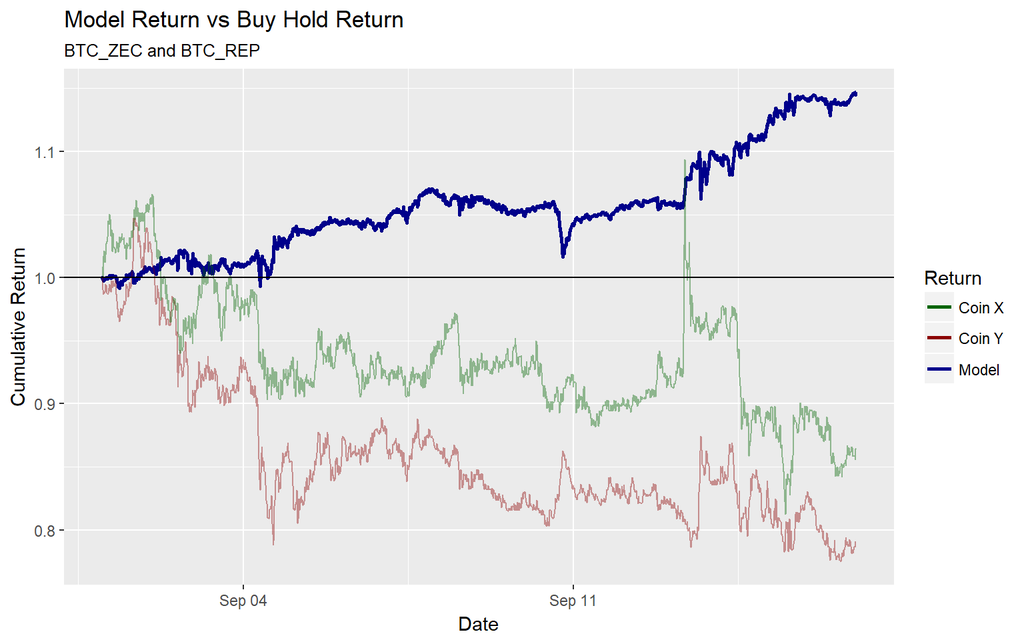

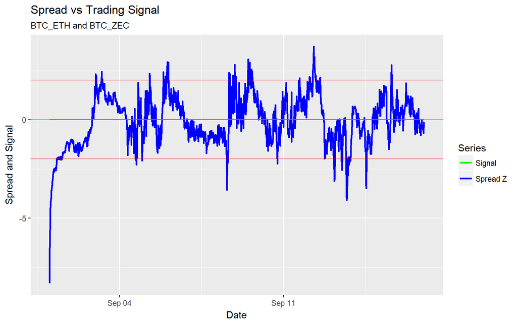

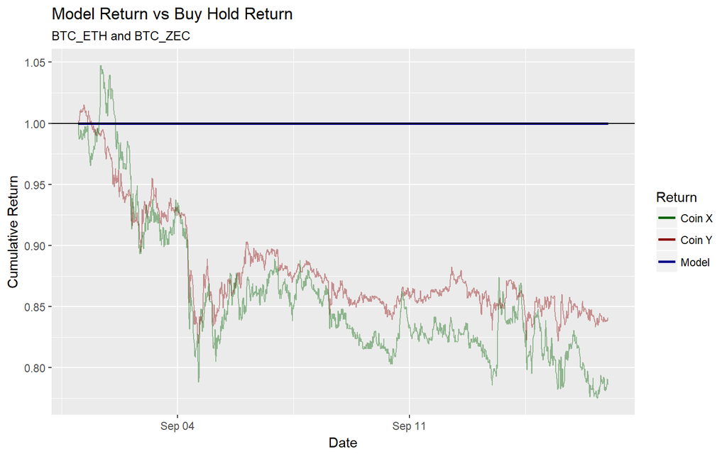

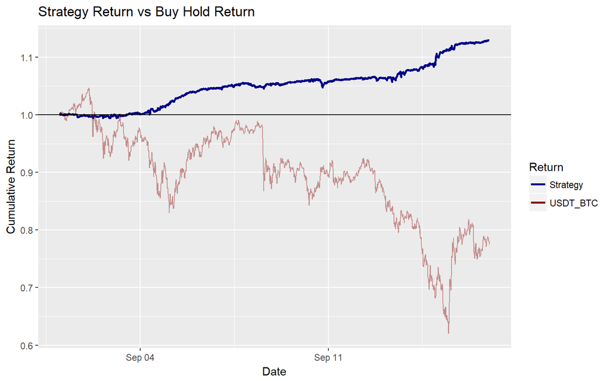

```r
plot_many(pricing_data = pricing_data,
          time_resolution = time_resolution,
          cutoff_date = "2017-09-01",
          train_window = train_window,
          test_window = test_window,
          quote_currency = quote_currency,
          rolling_window = rolling_window,
          number_pairs = number_pairs)
```

# 16. Cross Validation August 2017

```
## # A tibble: 9 x 3
##     coin_y   coin_x  adf_stat
##      <chr>    <chr>     <dbl>
## 1  BTC_ETH  BTC_ZEC -5.602468
## 2  BTC_ZEC  BTC_ETH -5.486184
## 3  BTC_ETH  BTC_REP -4.189460
## 4  BTC_ZEC  BTC_REP -3.981877
## 5  BTC_REP  BTC_ETH -3.942809
## 6  BTC_REP  BTC_ZEC -3.883980
## 7 BTC_DASH  BTC_XMR -3.677335
## 8  BTC_XEM  BTC_XMR -3.643599
## 9  BTC_XMR BTC_DASH -3.472615
```

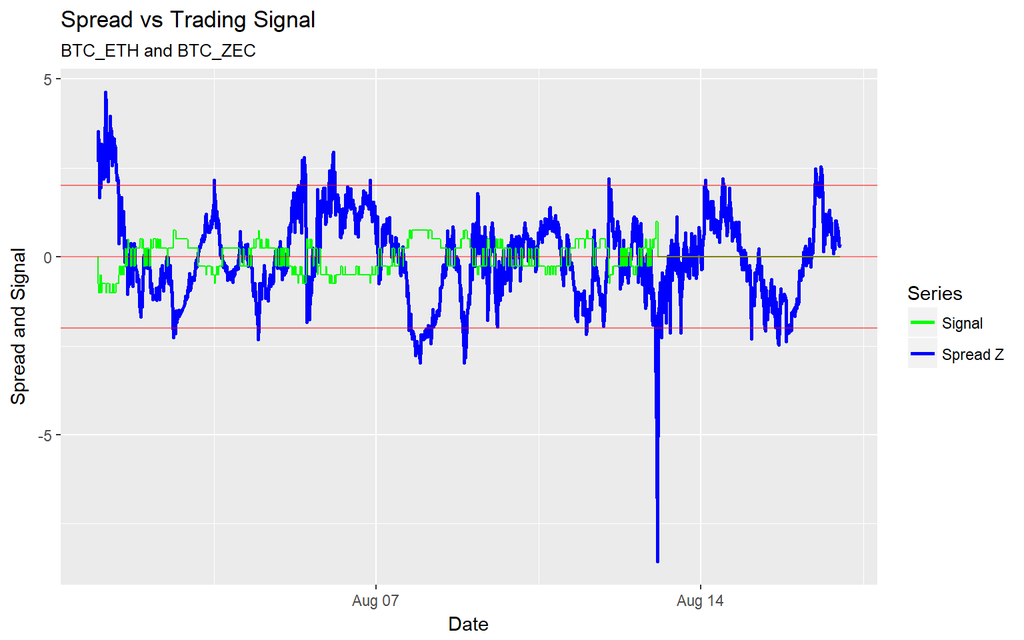

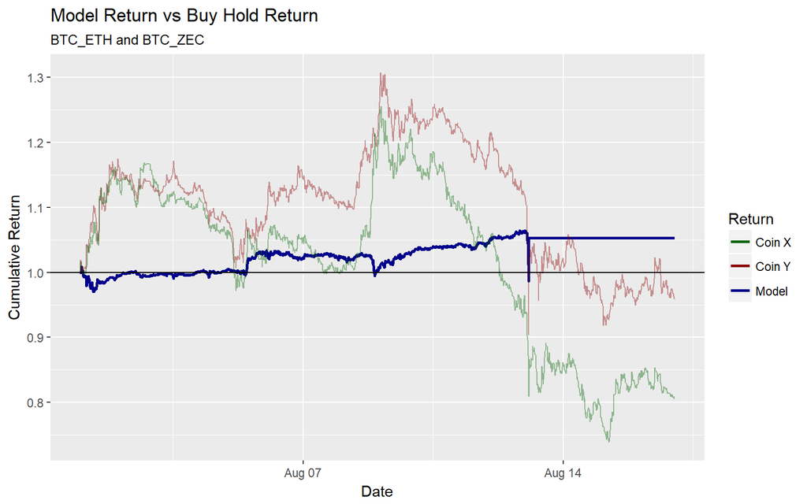

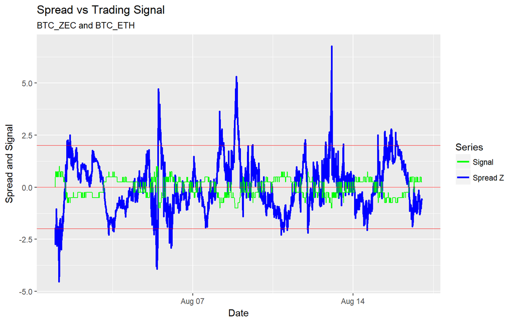

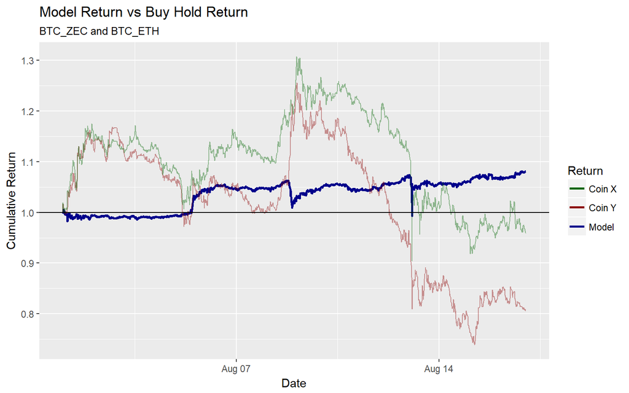

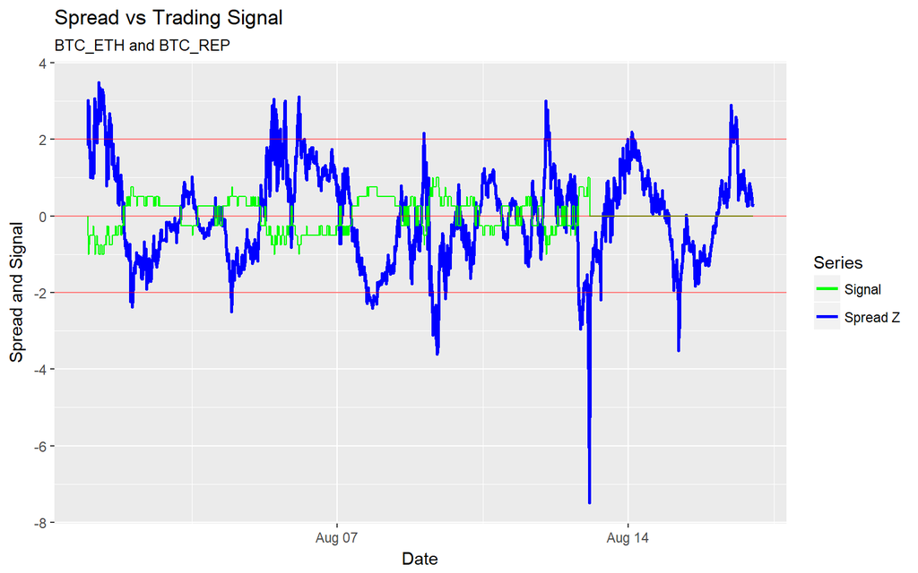

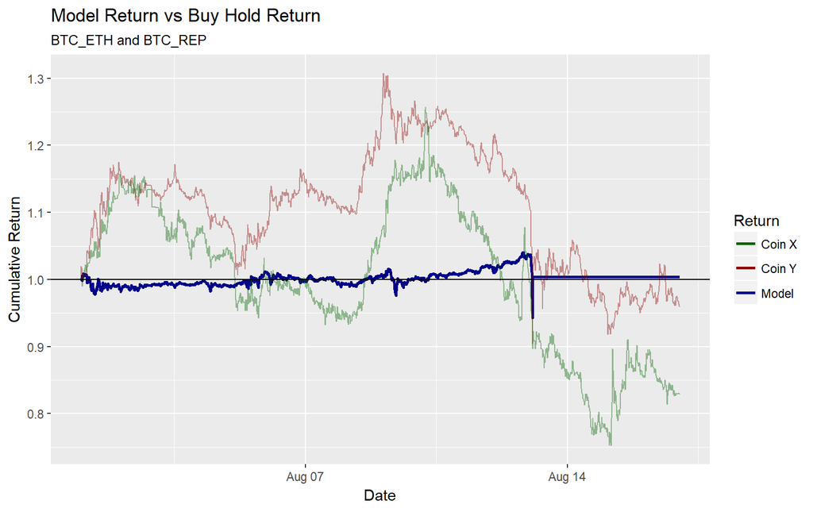

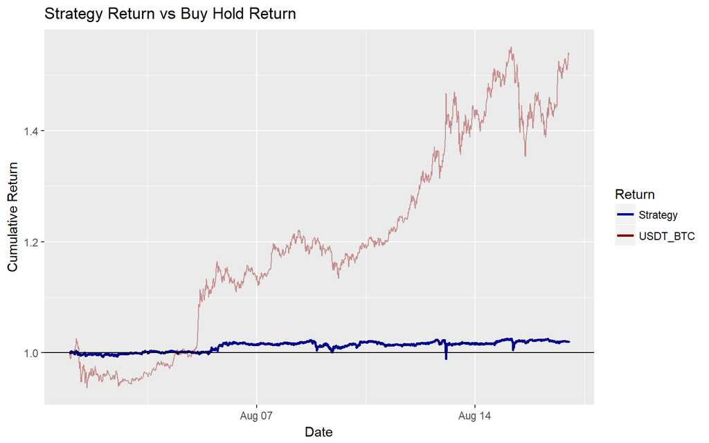

```r
plot_many(pricing_data = pricing_data,
          time_resolution = time_resolution,
          cutoff_date = "2017-08-01",
          train_window = train_window,
          test_window = test_window,
          quote_currency = quote_currency,
          rolling_window = rolling_window,
          number_pairs = number_pairs)
```

# 17. Cross Validation July 2017

```
## # A tibble: 3 x 3
##    coin_y  coin_x  adf_stat
##     <chr>   <chr>     <dbl>
## 1 BTC_XMR BTC_REP -4.731286
## 2 BTC_REP BTC_XMR -4.559391
## 3 BTC_XMR BTC_ETH -3.477126
```

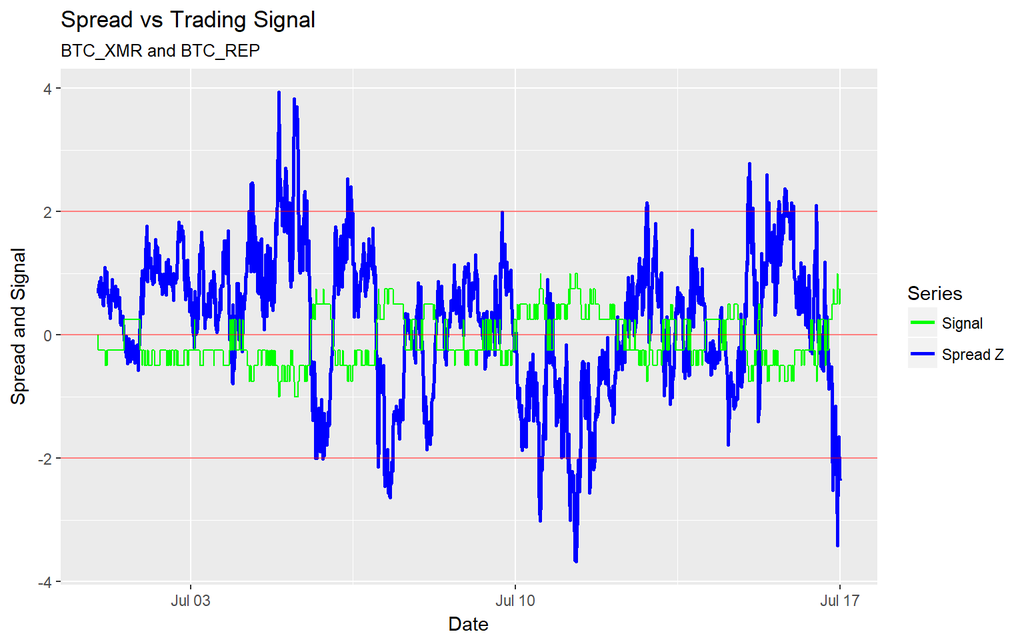

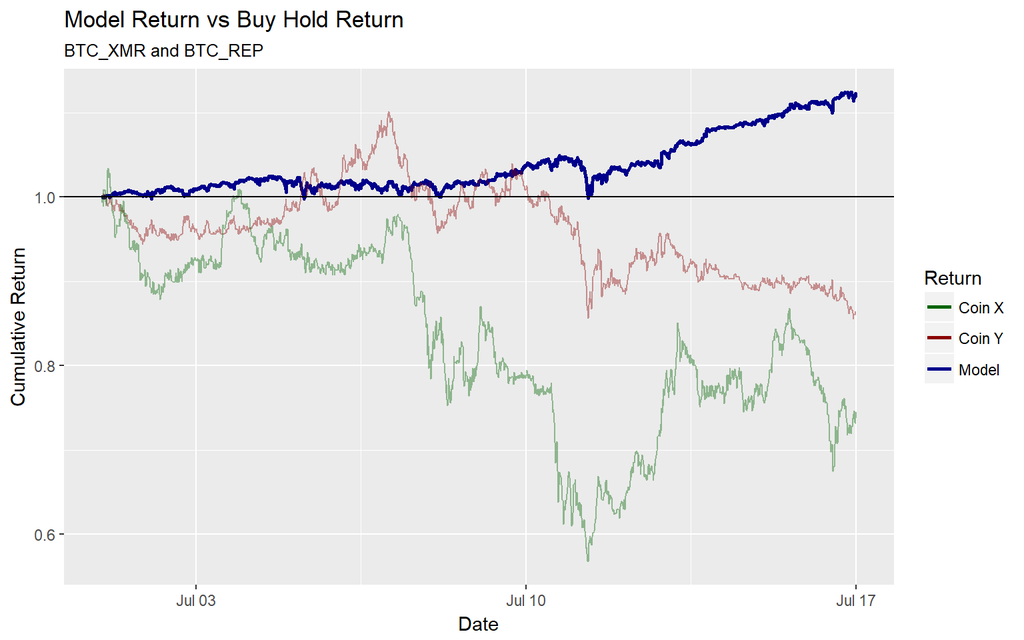

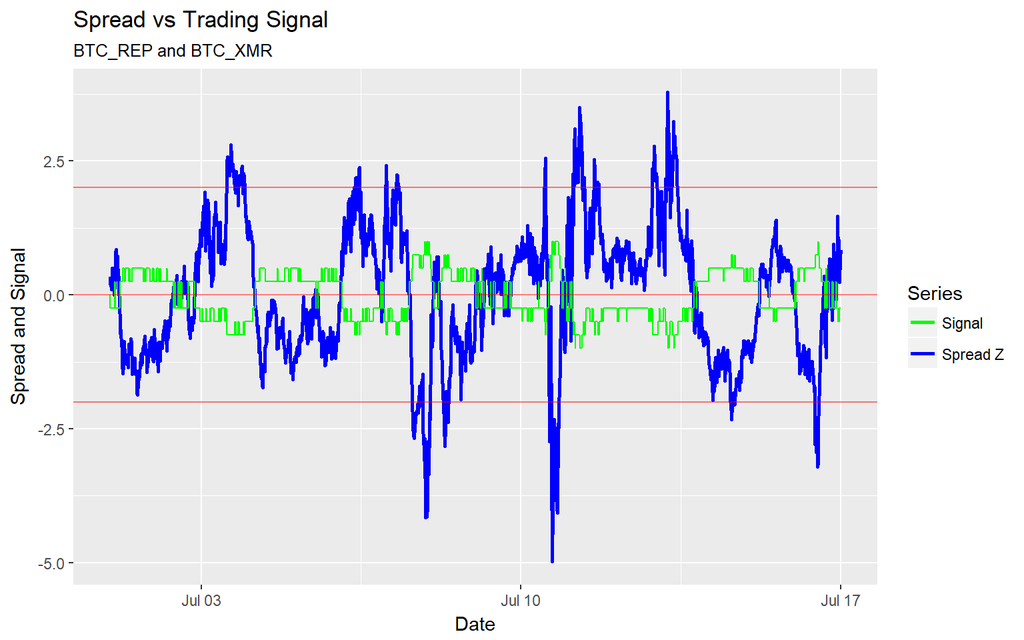

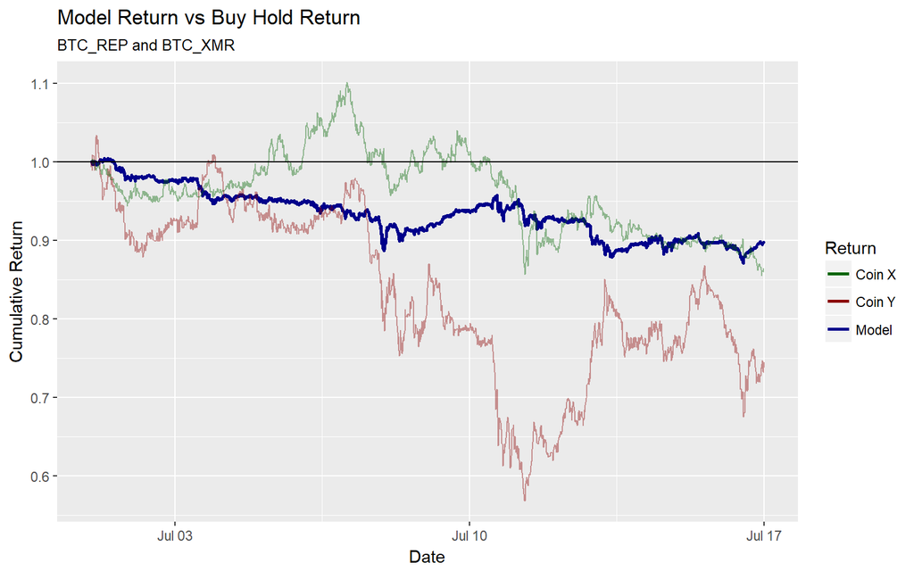

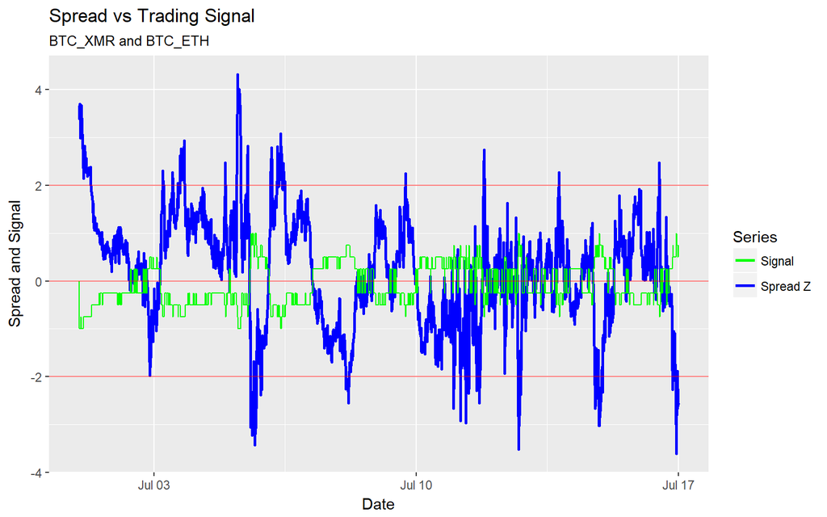

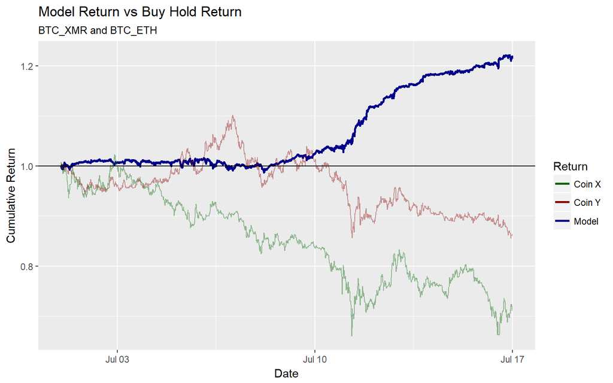

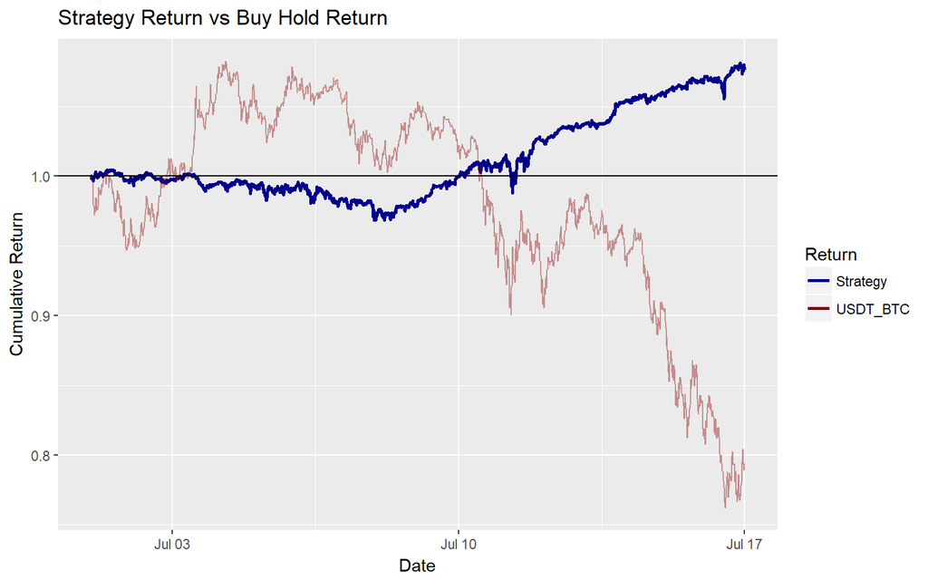

```r
plot_many(pricing_data = pricing_data,
          time_resolution = time_resolution,
          cutoff_date = "2017-07-01",
          train_window = train_window,
          test_window = test_window,
          quote_currency = quote_currency,
          rolling_window = rolling_window,
          number_pairs = number_pairs)
```

# 18. Cross Validation June 2017

```
## # A tibble: 9 x 3
##     coin_y   coin_x  adf_stat
##      <chr>    <chr>     <dbl>
## 1  BTC_REP BTC_DASH -5.585866
## 2 BTC_DASH  BTC_REP -5.575748
## 3  BTC_XMR  BTC_ZEC -4.142801
## 4  BTC_XMR  BTC_REP -3.959087
## 5  BTC_REP  BTC_XMR -3.803859
## 6  BTC_XMR BTC_DASH -3.718922
## 7 BTC_DASH  BTC_XMR -3.583567
## 8  BTC_XMR  BTC_ETH -3.580314
## 9  BTC_ZEC  BTC_ETH -3.540196
```

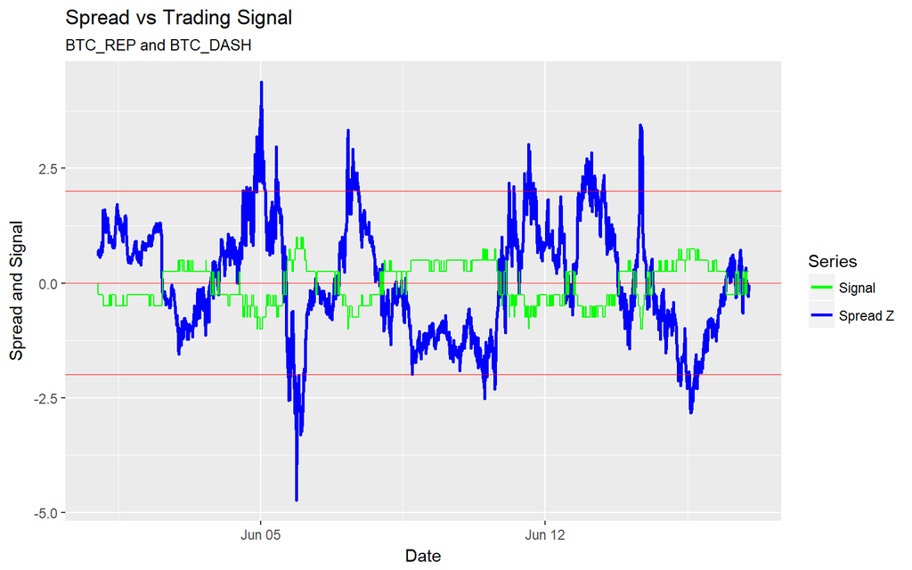

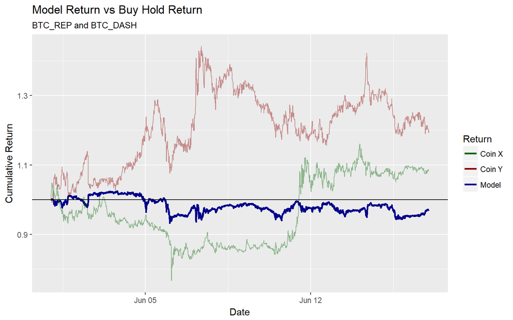

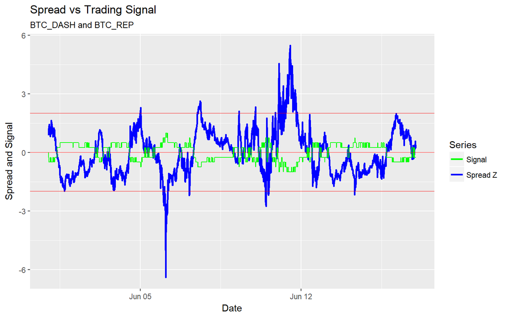

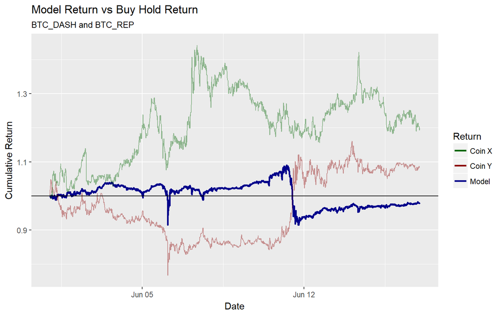

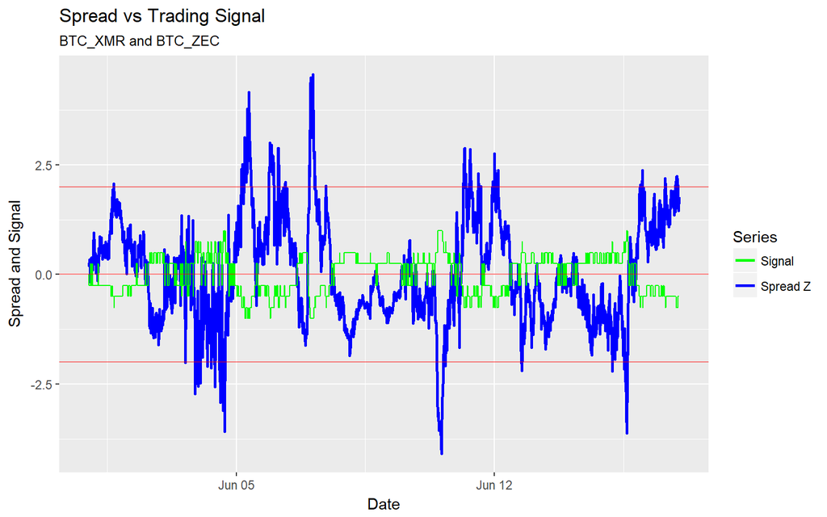

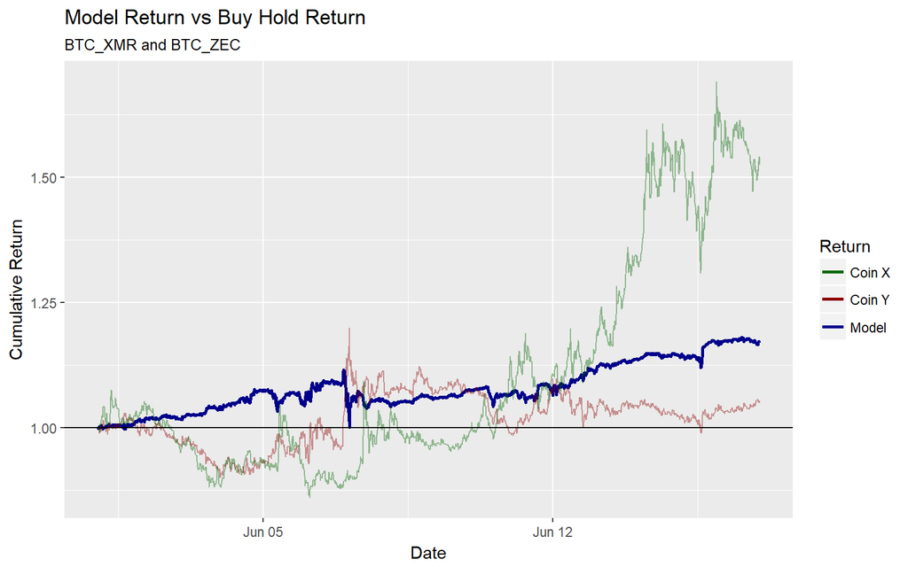

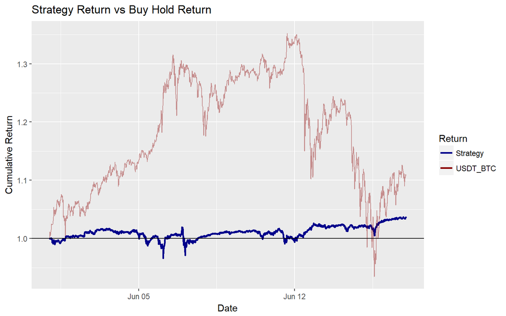

```r
plot_many(pricing_data = pricing_data,
          time_resolution = time_resolution,
          cutoff_date = "2017-06-01",
          train_window = train_window,
          test_window = test_window,
          quote_currency = quote_currency,
          rolling_window = rolling_window,
          number_pairs = number_pairs)
```